# Generating SQL for SQLite using Ollama, ChromaDB

This notebook runs through the process of using the `vanna` Python package to generate SQL using AI (RAG + LLMs) including connecting to a database and training. If you're not ready to train on your own database, you can still try it using a sample SQLite database.

### Which LLM do you want to use?

- OpenAI via Vanna.AI (Recommended)

  Use Vanna.AI for free to generate your queries
- OpenAI

  Use OpenAI with your own API key
- Azure OpenAI

  If you have OpenAI models deployed on Azure
- Ollama

  Use Ollama locally for free. Requires additional setup.
- Mistral via Mistral API

  If you have a Mistral API key
- Other LLM

  If you have a different LLM model

### Where do you want to store the 'training' data?

- Vanna Hosted Vector DB (Recommended)

  Use Vanna.AIs hosted vector database (pgvector) for free. This is usable across machines with no additional setup.
- ChromaDB

  Use ChromaDBs open-source vector database for free locally. No additional setup is necessary -- all database files will be created and stored locally.
- Marqo

  Use Marqo locally for free. Requires additional setup. Or use their hosted option.
- Other VectorDB

  Use any other vector database. Requires additional setup.

## Setup

```python
import warnings
import re

warnings.filterwarnings('ignore', category=DeprecationWarning, message='^Number of requested results')
# warnings.filterwarnings('ignore', category=DeprecationWarning, message=re.escape(r'^Some regex pattern'))

import os

import re
from time import time

from vanna.ollama import Ollama
from vanna.chromadb.chromadb_vector import ChromaDB_VectorStore
```

```python
class MyVanna(ChromaDB_VectorStore, Ollama):
    def __init__(self, config=None):
        ChromaDB_VectorStore.__init__(self, config=config)
        Ollama.__init__(self, config=config)
```

```python
file_db = "~/Downloads/chinook.sqlite"
model_name = "gemma2" # 'llama3'

clean_and_train = True  # False
```

```python
config = {
    'model': model_name,   # 'mistral' # "starcoder2"
}
vn = MyVanna(config=config)
```

```python
hostname = os.uname().nodename
print("Hostname:", hostname)
```

```
Hostname: ducklover1
```

```python
file_db = os.path.abspath(os.path.expanduser(file_db))
vn.connect_to_sqlite(file_db)
```

```python
vn.run_sql_is_set
```

```
True
```

```python
def remove_collections(collection_name=None, ACCEPTED_TYPES = ["sql", "ddl", "documentation"]):
    if not collection_name:
        collections = ACCEPTED_TYPES
    elif isinstance(collection_name, str):
        collections = [collection_name]
    elif isinstance(collection_name, list):
        collections = collection_name
    else:
        print(f"\t{collection_name} is unknown: Skipped")
        return

    for c in collections:
        if not c in ACCEPTED_TYPES:
            print(f"\t{c} is unknown: Skipped")
            continue

        # print(f"vn.remove_collection('{c}')")
        vn.remove_collection(c)
```

```python
def strip_brackets(ddl):
    """
    This function removes square brackets from table and column names in a DDL script.

    Args:
        ddl (str): The DDL script containing square brackets.

    Returns:
        str: The DDL script with square brackets removed.
    """
    # Use regular expressions to match and replace square brackets
    pattern = r"\[([^\]]+)]"  # Match any character except ] within square brackets
    return re.sub(pattern, r"\1", ddl)
```

```python
if clean_and_train:
    remove_collections()
```

## Training

### [SQLite sample database](https://www.sqlitetutorial.net/sqlite-sample-database/)

You only need to train once. Do not train again unless you want to add more training data.

```python
df_ddl = vn.run_sql("SELECT type, sql FROM sqlite_master WHERE sql is not null")
```

```python
df_ddl
```

|  | type | sql |
| --- | --- | --- |
| 0 | table | CREATE TABLE "albums"\r\n(\r\n [AlbumId] IN... |
| 1 | table | CREATE TABLE sqlite_sequence(name,seq) |
| 2 | table | CREATE TABLE "artists"\r\n(\r\n [ArtistId] ... |
| 3 | table | CREATE TABLE "customers"\r\n(\r\n [Customer... |
| 4 | table | CREATE TABLE "employees"\r\n(\r\n [Employee... |
| 5 | table | CREATE TABLE "genres"\r\n(\r\n [GenreId] IN... |
| 6 | table | CREATE TABLE "invoices"\r\n(\r\n [InvoiceId... |
| 7 | table | CREATE TABLE "invoice_items"\r\n(\r\n [Invo... |
| 8 | table | CREATE TABLE "media_types"\r\n(\r\n [MediaT... |
| 9 | table | CREATE TABLE "playlists"\r\n(\r\n [Playlist... |
| 10 | table | CREATE TABLE "playlist_track"\r\n(\r\n [Pla... |
| 11 | table | CREATE TABLE "tracks"\r\n(\r\n [TrackId] IN... |
| 12 | index | CREATE INDEX [IFK_AlbumArtistId] ON "albums" (... |
| 13 | index | CREATE INDEX [IFK_CustomerSupportRepId] ON "cu... |
| 14 | index | CREATE INDEX [IFK_EmployeeReportsTo] ON "emplo... |
| 15 | index | CREATE INDEX [IFK_InvoiceCustomerId] ON "invoi... |
| 16 | index | CREATE INDEX [IFK_InvoiceLineInvoiceId] ON "in... |
| 17 | index | CREATE INDEX [IFK_InvoiceLineTrackId] ON "invo... |
| 18 | index | CREATE INDEX [IFK_PlaylistTrackTrackId] ON "pl... |
| 19 | index | CREATE INDEX [IFK_TrackAlbumId] ON "tracks" ([... |
| 20 | index | CREATE INDEX [IFK_TrackGenreId] ON "tracks" ([... |
| 21 | index | CREATE INDEX [IFK_TrackMediaTypeId] ON "tracks... |
| 22 | table | CREATE TABLE sqlite_stat1(tbl,idx,stat) |

```python
if clean_and_train:
    for ddl in df_ddl['sql'].to_list():
        ddl = strip_brackets(ddl)
        vn.train(ddl=ddl)

    # Sometimes you may want to add documentation about your business terminology or definitions.
    vn.train(documentation="In the chinook database invoice means order")
```

```
Adding ddl: CREATE TABLE "albums"
(
    AlbumId INTEGER PRIMARY KEY AUTOINCREMENT NOT NULL,
    Title NVARCHAR(160)  NOT NULL,
    ArtistId INTEGER  NOT NULL,
    FOREIGN KEY (ArtistId) REFERENCES "artists" (ArtistId)
		ON DELETE NO ACTION ON UPDATE NO ACTION
)
Adding ddl: CREATE TABLE sqlite_sequence(name,seq)
Adding ddl: CREATE TABLE "artists"
(
    ArtistId INTEGER PRIMARY KEY AUTOINCREMENT NOT NULL,
    Name NVARCHAR(120)
)
Adding ddl: CREATE TABLE "customers"
(
    CustomerId INTEGER PRIMARY KEY AUTOINCREMENT NOT NULL,
    FirstName NVARCHAR(40)  NOT NULL,
    LastName NVARCHAR(20)  NOT NULL,
    Company NVARCHAR(80),
    Address NVARCHAR(70),
    City NVARCHAR(40),
    State NVARCHAR(40),
    Country NVARCHAR(40),
    PostalCode NVARCHAR(10),
    Phone NVARCHAR(24),
    Fax NVARCHAR(24),
    Email NVARCHAR(60)  NOT NULL,
    SupportRepId INTEGER,
    FOREIGN KEY (SupportRepId) REFERENCES "employees" (EmployeeId)
		ON DELETE NO ACTION ON UPDATE NO ACTION
)
Adding ddl: CREATE TABLE "employees"
(
    EmployeeId INTEGER PRIMARY KEY AUTOINCREMENT NOT NULL,
    LastName NVARCHAR(20)  NOT NULL,
    FirstName NVARCHAR(20)  NOT NULL,
    Title NVARCHAR(30),
    ReportsTo INTEGER,
    BirthDate DATETIME,
```

[output cut: 78 more lines]

```
    FOREIGN KEY (MediaTypeId) REFERENCES "media_types" (MediaTypeId)
		ON DELETE NO ACTION ON UPDATE NO ACTION
)
Adding ddl: CREATE INDEX IFK_AlbumArtistId ON "albums" (ArtistId)
Adding ddl: CREATE INDEX IFK_CustomerSupportRepId ON "customers" (SupportRepId)
Adding ddl: CREATE INDEX IFK_EmployeeReportsTo ON "employees" (ReportsTo)
Adding ddl: CREATE INDEX IFK_InvoiceCustomerId ON "invoices" (CustomerId)
Adding ddl: CREATE INDEX IFK_InvoiceLineInvoiceId ON "invoice_items" (InvoiceId)
Adding ddl: CREATE INDEX IFK_InvoiceLineTrackId ON "invoice_items" (TrackId)
Adding ddl: CREATE INDEX IFK_PlaylistTrackTrackId ON "playlist_track" (TrackId)
Adding ddl: CREATE INDEX IFK_TrackAlbumId ON "tracks" (AlbumId)
Adding ddl: CREATE INDEX IFK_TrackGenreId ON "tracks" (GenreId)
Adding ddl: CREATE INDEX IFK_TrackMediaTypeId ON "tracks" (MediaTypeId)
Adding ddl: CREATE TABLE sqlite_stat1(tbl,idx,stat)
Adding documentation....
```

```python
# show training data
training_data = vn.get_training_data()
training_data
```

|  | id | question | content | training_data_type |
| --- | --- | --- | --- | --- |
| 0 | 039f9d54-59f7-5f29-8c04-14dbc3e95671-ddl | None | CREATE TABLE "artists"\r\n(\r\n ArtistId IN... | ddl |
| 1 | 0db84e3d-ef41-563c-803e-21c1b985dc19-ddl | None | CREATE TABLE "invoices"\r\n(\r\n InvoiceId ... | ddl |
| 2 | 10cba811-ddba-5042-9e90-d764dfcd1629-ddl | None | CREATE INDEX IFK_InvoiceCustomerId ON "invoice... | ddl |
| 3 | 2c711317-b93d-5f60-a728-cb1c6fcbc040-ddl | None | CREATE INDEX IFK_CustomerSupportRepId ON "cust... | ddl |
| 4 | 37319c81-65f7-50ee-956b-795de244bee5-ddl | None | CREATE TABLE sqlite_stat1(tbl,idx,stat) | ddl |
| 5 | 40bd77cd-e1de-5872-8693-624117ff413c-ddl | None | CREATE INDEX IFK_InvoiceLineInvoiceId ON "invo... | ddl |
| 6 | 41130543-7164-562a-90a7-0fd0a409c154-ddl | None | CREATE TABLE "albums"\r\n(\r\n AlbumId INTE... | ddl |
| 7 | 458debc8-8082-5450-a17a-66028bd55ace-ddl | None | CREATE TABLE "playlists"\r\n(\r\n PlaylistI... | ddl |
| 8 | 4815f3fd-925b-53ce-9dfa-0e4285d5abd3-ddl | None | CREATE TABLE "invoice_items"\r\n(\r\n Invoi... | ddl |
| 9 | 48d484e9-984c-58ff-b391-75521c69d486-ddl | None | CREATE INDEX IFK_PlaylistTrackTrackId ON "play... | ddl |
| 10 | 551e1120-a6ee-554f-8b8a-ccf4f22d3636-ddl | None | CREATE INDEX IFK_AlbumArtistId ON "albums" (Ar... | ddl |
| 11 | 5ff4911e-45c1-5a59-9566-243a9b6a3320-ddl | None | CREATE TABLE "employees"\r\n(\r\n EmployeeI... | ddl |
| 12 | 65df0648-bf05-5f75-9365-c21f54b2302d-ddl | None | CREATE TABLE "media_types"\r\n(\r\n MediaTy... | ddl |
| 13 | 6b585176-e66d-5b23-8d86-ca8a80e3af3d-ddl | None | CREATE INDEX IFK_EmployeeReportsTo ON "employe... | ddl |
| 14 | 868758b8-e018-55e7-8cc3-75c0e6d211c8-ddl | None | CREATE INDEX IFK_TrackAlbumId ON "tracks" (Alb... | ddl |
| 15 | 9ea4613d-c1be-5a77-ada9-c54ee3f0cab7-ddl | None | CREATE INDEX IFK_TrackMediaTypeId ON "tracks" ... | ddl |
| 16 | a9c9a852-608d-5ef2-aede-26ba098d83d1-ddl | None | CREATE INDEX IFK_TrackGenreId ON "tracks" (Gen... | ddl |
| 17 | b42cc9e1-9219-5a42-9a06-de906f76239e-ddl | None | CREATE TABLE "tracks"\r\n(\r\n TrackId INTE... | ddl |
| 18 | c387b9d2-5ff4-5a07-8364-f5dab45bb2a9-ddl | None | CREATE TABLE "genres"\r\n(\r\n GenreId INTE... | ddl |
| 19 | d654f328-dc36-549e-84c3-06ee0db7e0f7-ddl | None | CREATE TABLE "playlist_track"\r\n(\r\n Play... | ddl |
| 20 | d93f0d68-023d-5afb-8121-ba346699d318-ddl | None | CREATE TABLE "customers"\r\n(\r\n CustomerI... | ddl |
| 21 | e5879308-329e-543f-a693-0c14e2f9972e-ddl | None | CREATE INDEX IFK_InvoiceLineTrackId ON "invoic... | ddl |
| 22 | ea84418b-1a28-59b4-a1f4-2fb674208adc-ddl | None | CREATE TABLE sqlite_sequence(name,seq) | ddl |
| 0 | 2b4dda0a-a6ac-5e34-8f76-e41c0734d55e-doc | None | In the chinook database invoice means order | documentation |

## Asking the AI

Whenever you ask a new question, it will find the 10 most relevant pieces of training data and use it as part of the LLM prompt to generate the SQL.

```python
ts_start = time()
```

[output not shown]

```
Number of requested results 10 is greater than number of elements in index 1, updating n_results = 1
```

````
SQL Prompt: [{'role': 'system', 'content': 'You are a SQLite expert. Please help to generate a SQL query to answer the question. Your response should ONLY be based on the given context and follow the response guidelines and format instructions. \n===Tables \nCREATE TABLE sqlite_stat1(tbl,idx,stat)\n…
Info: Ollama parameters:
model=gemma2:latest,
options={},
keep_alive=None
Info: Prompt Content:
[{"role": "system", "content": "You are a SQLite expert. Please help to generate a SQL query to answer the question. Your response should ONLY be based on the given context and follow the response guidelines and format instructions. \n===Tables \nCREATE TABLE sqlite_stat1(tbl,idx,stat)\n\nCREATE TAB…
Info: Ollama Response:
{'model': 'gemma2:latest', 'created_at': '2024-08-01T18:37:49.471387611Z', 'message': {'role': 'assistant', 'content': "SELECT name FROM sqlite_master WHERE type='table';  \r\n"}, 'done_reason': 'stop', 'done': True, 'total_duration': 42445754181, 'load_duration': 4380960695, 'prompt_eval_count': 84…
LLM Response: SELECT name FROM sqlite_master WHERE type='table';

Info: Output from LLM: SELECT name FROM sqlite_master WHERE type='table';

Extracted SQL: SELECT name FROM sqlite_master WHERE type='table'
SELECT name FROM sqlite_master WHERE type='table'
               name
0            albums
1   sqlite_sequence
2           artists
3         customers
4         employees
5            genres
6          invoices
7     invoice_items
8       media_types
9         playlists
10   playlist_track
11           tracks
12     sqlite_stat1
Info: Ollama parameters:
model=gemma2:latest,
options={},
keep_alive=None
Info: Prompt Content:
[{"role": "system", "content": "The following is a pandas DataFrame that contains the results of the query that answers the question the user asked: 'Can you list all tables in the SQLite database catalog?'\n\nThe DataFrame was produced using this query: SELECT name FROM sqlite_master WHERE type='ta…
Info: Ollama Response:
{'model': 'gemma2:latest', 'created_at': '2024-08-01T18:38:17.42997324Z', 'message': {'role': 'assistant', 'content': '```python\nimport plotly.express as px\n\nif df.shape[0] == 1:\n  px.indicator(\n    value=df[\'name\'].iloc[0],\n    title="SQLite Database Tables",\n    domain={\'x\': [0, 1], \'y…
````

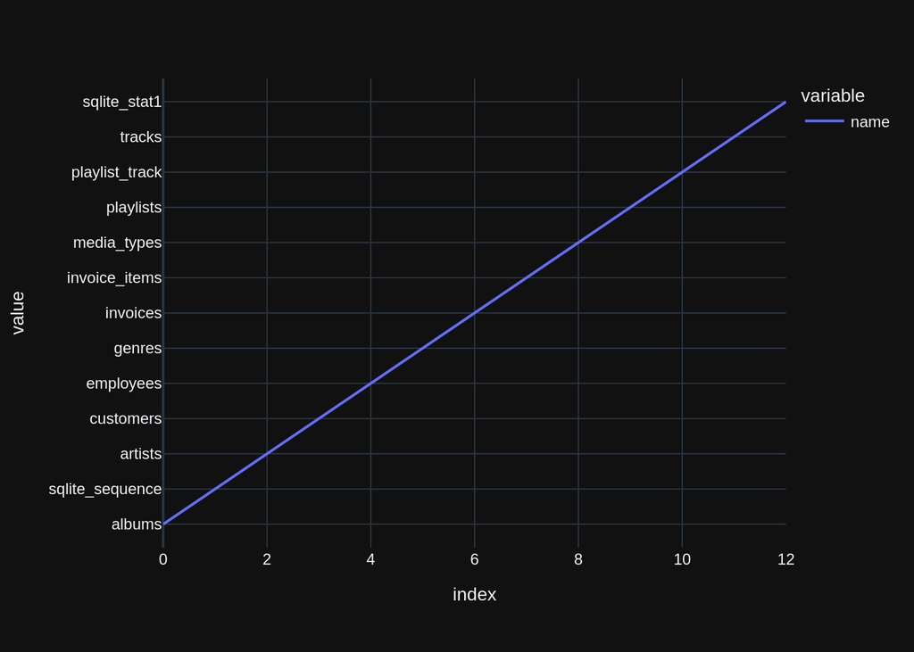

[output not shown]

```python
vn.ask(question="Can you list all tables in the SQLite database catalog?")
```

```python
vn.ask(question="which table stores customer's orders")
```

```
Number of requested results 10 is greater than number of elements in index 1, updating n_results = 1
Number of requested results 10 is greater than number of elements in index 1, updating n_results = 1
```

```
SQL Prompt: [{'role': 'system', 'content': 'You are a SQLite expert. Please help to generate a SQL query to answer the question. Your response should ONLY be based on the given context and follow the response guidelines and format instructions. \n===Tables \nCREATE TABLE "invoices"\r\n(\r\n    Invoi…
Info: Ollama parameters:
model=gemma2:latest,
options={},
keep_alive=None
Info: Prompt Content:
[{"role": "system", "content": "You are a SQLite expert. Please help to generate a SQL query to answer the question. Your response should ONLY be based on the given context and follow the response guidelines and format instructions. \n===Tables \nCREATE TABLE \"invoices\"\r\n(\r\n    InvoiceId INTEG…
Info: Ollama Response:
{'model': 'gemma2:latest', 'created_at': '2024-08-01T18:39:09.56174088Z', 'message': {'role': 'assistant', 'content': 'invoices  \r\n'}, 'done_reason': 'stop', 'done': True, 'total_duration': 51696360533, 'load_duration': 16051482, 'prompt_eval_count': 1104, 'prompt_eval_duration': 50469647000, 'eva…
LLM Response: invoices

invoices

Couldn't run sql:  Execution failed on sql 'invoices
': near "invoices": syntax error
```

```
Number of requested results 10 is greater than number of elements in index 1, updating n_results = 1
Number of requested results 10 is greater than number of elements in index 1, updating n_results = 1
```

````
SQL Prompt: [{'role': 'system', 'content': 'You are a SQLite expert. Please help to generate a SQL query to answer the question. Your response should ONLY be based on the given context and follow the response guidelines and format instructions. \n===Tables \nCREATE TABLE "invoices"\r\n(\r\n    Invoi…
Info: Ollama parameters:
model=gemma2:latest,
options={},
keep_alive=None
Info: Prompt Content:
[{"role": "system", "content": "You are a SQLite expert. Please help to generate a SQL query to answer the question. Your response should ONLY be based on the given context and follow the response guidelines and format instructions. \n===Tables \nCREATE TABLE \"invoices\"\r\n(\r\n    InvoiceId INTEG…
Info: Ollama Response:
{'model': 'gemma2:latest', 'created_at': '2024-08-01T18:39:50.61267405Z', 'message': {'role': 'assistant', 'content': 'SELECT COUNT(*) FROM customers;  \n'}, 'done_reason': 'stop', 'done': True, 'total_duration': 41008898334, 'load_duration': 24204733, 'prompt_eval_count': 1013, 'prompt_eval_duratio…
LLM Response: SELECT COUNT(*) FROM customers;

Info: Output from LLM: SELECT COUNT(*) FROM customers;

Extracted SQL: SELECT COUNT(*) FROM customers
SELECT COUNT(*) FROM customers
   COUNT(*)
0        59
Info: Ollama parameters:
model=gemma2:latest,
options={},
keep_alive=None
Info: Prompt Content:
[{"role": "system", "content": "The following is a pandas DataFrame that contains the results of the query that answers the question the user asked: 'How many customers are there'\n\nThe DataFrame was produced using this query: SELECT COUNT(*) FROM customers\n\nThe following is information about the…
Info: Ollama Response:
{'model': 'gemma2:latest', 'created_at': '2024-08-01T18:40:04.843770134Z', 'message': {'role': 'assistant', 'content': '```python\nimport plotly.express as px\n\nfig = px.indicator(df, \n                   value="COUNT(*)", \n                   title="Number of Customers")\n```'}, 'done_reason': 'st…
````

[figure not shown]

```
('SELECT COUNT(*) FROM customers',
    COUNT(*)
 0        59,
 Figure({
     'data': [{'hovertemplate': 'variable=COUNT(*)<br>index=%{x}<br>value=%{y}<extra></extra>',
               'legendgroup': 'COUNT(*)',
               'line': {'color': '#636efa', 'dash': 'solid'},
               'marker': {'symbol': 'circle'},
               'mode': 'lines',
               'name': 'COUNT(*)',
               'orientation': 'v',
               'showlegend': True,
               'type': 'scatter',
               'x': array([0]),
               'xaxis': 'x',
               'y': array([59]),
               'yaxis': 'y'}],
     'layout': {'legend': {'title': {'text': 'variable'}, 'tracegroupgap': 0},
                'margin': {'t': 60},
                'template': '...',
                'xaxis': {'anchor': 'y', 'domain': [0.0, 1.0], 'title': {'text': 'index'}},
                'yaxis': {'anchor': 'x', 'domain': [0.0, 1.0], 'title': {'text': 'value'}}}
 }))
```

```python
vn.ask(question="How many customers are there")
```

```
Number of requested results 10 is greater than number of elements in index 2, updating n_results = 2
Number of requested results 10 is greater than number of elements in index 1, updating n_results = 1
```

````
SQL Prompt: [{'role': 'system', 'content': 'You are a SQLite expert. Please help to generate a SQL query to answer the question. Your response should ONLY be based on the given context and follow the response guidelines and format instructions. \n===Tables \nCREATE TABLE "invoices"\r\n(\r\n    Invoi…
Info: Ollama parameters:
model=gemma2:latest,
options={},
keep_alive=None
Info: Prompt Content:
[{"role": "system", "content": "You are a SQLite expert. Please help to generate a SQL query to answer the question. Your response should ONLY be based on the given context and follow the response guidelines and format instructions. \n===Tables \nCREATE TABLE \"invoices\"\r\n(\r\n    InvoiceId INTEG…
Info: Ollama Response:
{'model': 'gemma2:latest', 'created_at': '2024-08-01T18:41:12.771356777Z', 'message': {'role': 'assistant', 'content': 'SELECT Country, COUNT(*) AS CustomerCount \r\nFROM customers\r\nGROUP BY Country\r\nORDER BY CustomerCount DESC\r\nLIMIT 5;  \n\n\n\n'}, 'done_reason': 'stop', 'done': True, 'total…
LLM Response: SELECT Country, COUNT(*) AS CustomerCount
FROM customers
GROUP BY Country
ORDER BY CustomerCount DESC
LIMIT 5;




Info: Output from LLM: SELECT Country, COUNT(*) AS CustomerCount
FROM customers
GROUP BY Country
ORDER BY CustomerCount DESC
LIMIT 5;




Extracted SQL: SELECT Country, COUNT(*) AS CustomerCount
FROM customers
GROUP BY Country
ORDER BY CustomerCount DESC
LIMIT 5
SELECT Country, COUNT(*) AS CustomerCount
FROM customers
GROUP BY Country
ORDER BY CustomerCount DESC
LIMIT 5
   Country  CustomerCount
0      USA             13
1   Canada              8
2   France              5
3   Brazil              5
4  Germany              4
Info: Ollama parameters:
model=gemma2:latest,
options={},
keep_alive=None
Info: Prompt Content:
[{"role": "system", "content": "The following is a pandas DataFrame that contains the results of the query that answers the question the user asked: 'what are the top 5 countries that customers come from?'\n\nThe DataFrame was produced using this query: SELECT Country, COUNT(*) AS CustomerCount \r\n…
Info: Ollama Response:
{'model': 'gemma2:latest', 'created_at': '2024-08-01T18:41:39.3206708Z', 'message': {'role': 'assistant', 'content': '```python\nimport plotly.express as px\n\nif df.shape[0] == 1:\n  fig = px.indicator(df, name="CustomerCount", value=\'CustomerCount\', title=\'Top Country\')\nelse:\n  fig = px.bar(…
````

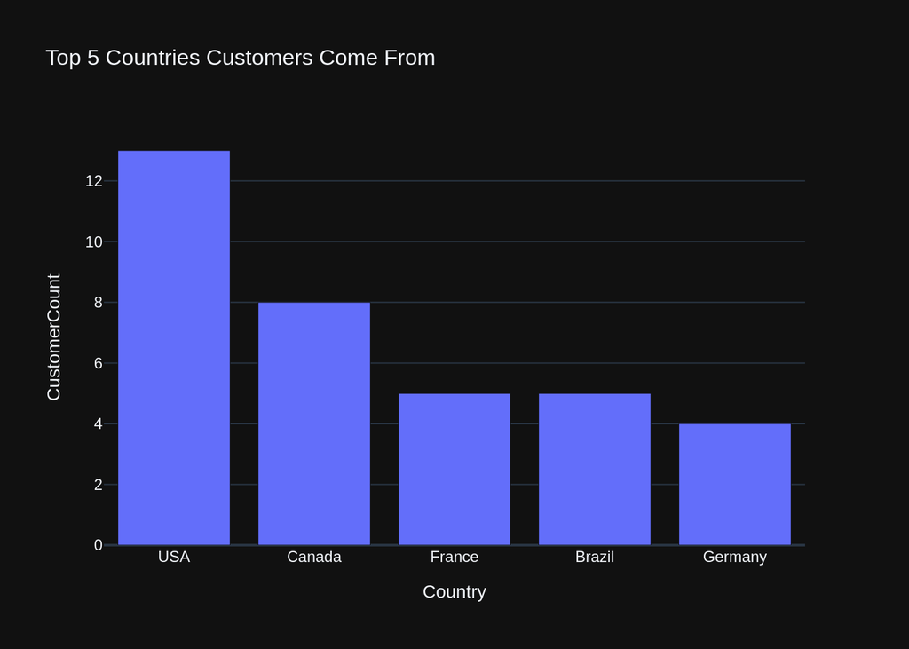

```
('SELECT Country, COUNT(*) AS CustomerCount \r\nFROM customers\r\nGROUP BY Country\r\nORDER BY CustomerCount DESC\r\nLIMIT 5',
    Country  CustomerCount
 0      USA             13
 1   Canada              8
 2   France              5
 3   Brazil              5
 4  Germany              4,
 Figure({
     'data': [{'alignmentgroup': 'True',
               'hovertemplate': 'Country=%{x}<br>CustomerCount=%{y}<extra></extra>',
               'legendgroup': '',
               'marker': {'color': '#636efa', 'pattern': {'shape': ''}},
               'name': '',
               'offsetgroup': '',
               'orientation': 'v',
               'showlegend': False,
               'textposition': 'auto',
               'type': 'bar',
               'x': array(['USA', 'Canada', 'France', 'Brazil', 'Germany'], dtype=object),
               'xaxis': 'x',
               'y': array([13,  8,  5,  5,  4]),
               'yaxis': 'y'}],
     'layout': {'barmode': 'relative',
                'legend': {'tracegroupgap': 0},
                'template': '...',
                'title': {'text': 'Top 5 Countries Customers Come From'},
                'xaxis': {'anchor': 'y', 'domain': [0.0, 1.0], 'title': {'text': 'Country'}},
                'yaxis': {'anchor': 'x', 'domain': [0.0, 1.0], 'title': {'text': 'CustomerCount'}}}
 }))
```

```python
vn.ask(question="what are the top 5 countries that customers come from?")
```

### More SQL questions

see `sample-sql-queries-sqlite-chinook.ipynb`

```python
question = """
    List all albums and their corresponding artist names
"""

vn.ask(question=question)
```

```
Number of requested results 10 is greater than number of elements in index 3, updating n_results = 3
Number of requested results 10 is greater than number of elements in index 1, updating n_results = 1
```

```
SQL Prompt: [{'role': 'system', 'content': 'You are a SQLite expert. Please help to generate a SQL query to answer the question. Your response should ONLY be based on the given context and follow the response guidelines and format instructions. \n===Tables \nCREATE INDEX IFK_AlbumArtistId ON "albums…
Info: Ollama parameters:
model=gemma2:latest,
options={},
keep_alive=None
Info: Prompt Content:
[{"role": "system", "content": "You are a SQLite expert. Please help to generate a SQL query to answer the question. Your response should ONLY be based on the given context and follow the response guidelines and format instructions. \n===Tables \nCREATE INDEX IFK_AlbumArtistId ON \"albums\" (ArtistI…
Info: Ollama Response:
{'model': 'gemma2:latest', 'created_at': '2024-08-01T18:42:19.891324561Z', 'message': {'role': 'assistant', 'content': 'SELECT \n    a.Title,\n    ar.Name\nFROM albums AS a\nJOIN artists AS ar ON a.ArtistId = ar.ArtistId; \n'}, 'done_reason': 'stop', 'done': True, 'total_duration': 40471677704, 'loa…
LLM Response: SELECT
    a.Title,
    ar.Name
FROM albums AS a
JOIN artists AS ar ON a.ArtistId = ar.ArtistId;

Info: Output from LLM: SELECT
    a.Title,
    ar.Name
FROM albums AS a
JOIN artists AS ar ON a.ArtistId = ar.ArtistId;

Extracted SQL: SELECT
    a.Title,
    ar.Name
FROM albums AS a
JOIN artists AS ar ON a.ArtistId = ar.ArtistId
SELECT
    a.Title,
    ar.Name
FROM albums AS a
JOIN artists AS ar ON a.ArtistId = ar.ArtistId
                                                 Title  \
0                For Those About To Rock We Salute You
1                                    Balls to the Wall
2                                    Restless and Wild
3                                    Let There Be Rock
4                                             Big Ones
..                                                 ...
342                             Respighi:Pines of Rome
343  Schubert: The Late String Quartets & String Qu...
```

[output cut: 12 more lines]

````
343                             Emerson String Quartet
344  C. Monteverdi, Nigel Rogers - Chiaroscuro; Lon...
345                                      Nash Ensemble
346                              Philip Glass Ensemble

[347 rows x 2 columns]
Info: Ollama parameters:
model=gemma2:latest,
options={},
keep_alive=None
Info: Prompt Content:
[{"role": "system", "content": "The following is a pandas DataFrame that contains the results of the query that answers the question the user asked: '  \n    List all albums and their corresponding artist names  \n'\n\nThe DataFrame was produced using this query: SELECT \n    a.Title,\n    ar.Name\n…
Info: Ollama Response:
{'model': 'gemma2:latest', 'created_at': '2024-08-01T18:42:48.025921047Z', 'message': {'role': 'assistant', 'content': '```python\nimport plotly.express as px\n\nif df.shape[0] == 1:\n  px.indicator(\n    value=df[\'Title\'].iloc[0],\n    title="Album and Artist",\n    text=f"{df[\'Title\'].iloc[0]}…
Couldn't run plotly code:  'NoneType' object has no attribute 'show'
````

[output not shown]

```python
question = """
    Find all tracks with a name containing "What" (case-insensitive)
"""

vn.ask(question=question)
```

```
Number of requested results 10 is greater than number of elements in index 4, updating n_results = 4
Number of requested results 10 is greater than number of elements in index 1, updating n_results = 1
```

```
SQL Prompt: [{'role': 'system', 'content': 'You are a SQLite expert. Please help to generate a SQL query to answer the question. Your response should ONLY be based on the given context and follow the response guidelines and format instructions. \n===Tables \nCREATE INDEX IFK_TrackGenreId ON "tracks"…
Info: Ollama parameters:
model=gemma2:latest,
options={},
keep_alive=None
Info: Prompt Content:
[{"role": "system", "content": "You are a SQLite expert. Please help to generate a SQL query to answer the question. Your response should ONLY be based on the given context and follow the response guidelines and format instructions. \n===Tables \nCREATE INDEX IFK_TrackGenreId ON \"tracks\" (GenreId)…
Info: Ollama Response:
{'model': 'gemma2:latest', 'created_at': '2024-08-01T18:43:28.163143282Z', 'message': {'role': 'assistant', 'content': "SELECT * \r\nFROM tracks\r\nWHERE LOWER(Name) LIKE '%what%'; \n\n\n\n"}, 'done_reason': 'stop', 'done': True, 'total_duration': 40081813525, 'load_duration': 22732934, 'prompt_eval…
LLM Response: SELECT *
FROM tracks
WHERE LOWER(Name) LIKE '%what%';




Info: Output from LLM: SELECT *
FROM tracks
WHERE LOWER(Name) LIKE '%what%';




Extracted SQL: SELECT *
FROM tracks
WHERE LOWER(Name) LIKE '%what%'
SELECT *
FROM tracks
WHERE LOWER(Name) LIKE '%what%'
    TrackId                                          Name  AlbumId  \
0        26                                 What It Takes        5
1        88                                  What You Are       10
2       130                             Do what cha wanna       13
3       342                   What is and Should Never Be       30
4       607                                       So What       48
5       960                                    What A Day       76
6      1000                                 What If I Do?       80
7      1039                              What Now My Love       83
8      1145                                   Whatsername       89
9      1440             Whatever It Is, I Just Can't Stop      116
```

[output cut: 54 more lines]

````
16       2610250  484583988       1.99
17       2616410  183867185       1.99
18        353567   11542247       0.99
19        280764    9306737       0.99
20        215084    3499018       0.99
21        209573    3426106       0.99
Info: Ollama parameters:
model=gemma2:latest,
options={},
keep_alive=None
Info: Prompt Content:
[{"role": "system", "content": "The following is a pandas DataFrame that contains the results of the query that answers the question the user asked: '  \n    Find all tracks with a name containing \"What\" (case-insensitive)\n'\n\nThe DataFrame was produced using this query: SELECT * \r\nFROM tracks…
Info: Ollama Response:
{'model': 'gemma2:latest', 'created_at': '2024-08-01T18:43:53.532271089Z', 'message': {'role': 'assistant', 'content': "```python\nimport plotly.express as px\n\nif df.shape[0] == 1:\n  px.indicator(\n    value=df['Name'].iloc[0],\n    title='Track Name',\n    type='number'\n  )\nelse:\n  px.bar(df,…
Couldn't run plotly code:  'NoneType' object has no attribute 'show'
````

[output not shown]

```
Number of requested results 10 is greater than number of elements in index 5, updating n_results = 5
Number of requested results 10 is greater than number of elements in index 1, updating n_results = 1
```

```
SQL Prompt: [{'role': 'system', 'content': 'You are a SQLite expert. Please help to generate a SQL query to answer the question. Your response should ONLY be based on the given context and follow the response guidelines and format instructions. \n===Tables \nCREATE TABLE "invoices"\r\n(\r\n    Invoi…
Info: Ollama parameters:
model=gemma2:latest,
options={},
keep_alive=None
Info: Prompt Content:
[{"role": "system", "content": "You are a SQLite expert. Please help to generate a SQL query to answer the question. Your response should ONLY be based on the given context and follow the response guidelines and format instructions. \n===Tables \nCREATE TABLE \"invoices\"\r\n(\r\n    InvoiceId INTEG…
Info: Ollama Response:
{'model': 'gemma2:latest', 'created_at': '2024-08-01T18:44:56.028585994Z', 'message': {'role': 'assistant', 'content': 'SELECT CustomerId, COUNT(*) AS TotalInvoices\r\nFROM invoices\r\nGROUP BY CustomerId; \n\n\n'}, 'done_reason': 'stop', 'done': True, 'total_duration': 62441263807, 'load_duration':…
LLM Response: SELECT CustomerId, COUNT(*) AS TotalInvoices
FROM invoices
GROUP BY CustomerId;



Info: Output from LLM: SELECT CustomerId, COUNT(*) AS TotalInvoices
FROM invoices
GROUP BY CustomerId;



Extracted SQL: SELECT CustomerId, COUNT(*) AS TotalInvoices
FROM invoices
GROUP BY CustomerId
SELECT CustomerId, COUNT(*) AS TotalInvoices
FROM invoices
GROUP BY CustomerId
    CustomerId  TotalInvoices
0            1              7
1            2              7
2            3              7
3            4              7
4            5              7
5            6              7
6            7              7
7            8              7
8            9              7
9           10              7
10          11              7
11          12              7
```

[output cut: 40 more lines]

````
52          53              7
53          54              7
54          55              7
55          56              7
56          57              7
57          58              7
58          59              6
Info: Ollama parameters:
model=gemma2:latest,
options={},
keep_alive=None
Info: Prompt Content:
[{"role": "system", "content": "The following is a pandas DataFrame that contains the results of the query that answers the question the user asked: '  \n    Get the total number of invoices for each customer\n'\n\nThe DataFrame was produced using this query: SELECT CustomerId, COUNT(*) AS TotalInvo…
Info: Ollama Response:
{'model': 'gemma2:latest', 'created_at': '2024-08-01T18:45:23.037365275Z', 'message': {'role': 'assistant', 'content': '```python\nimport plotly.express as px\n\nif df.shape[0] == 1:\n  px.indicator(\n    value=df[\'TotalInvoices\'].iloc[0],\n    title="Total Invoices",\n  )\nelse:\n  fig = px.bar(d…
````

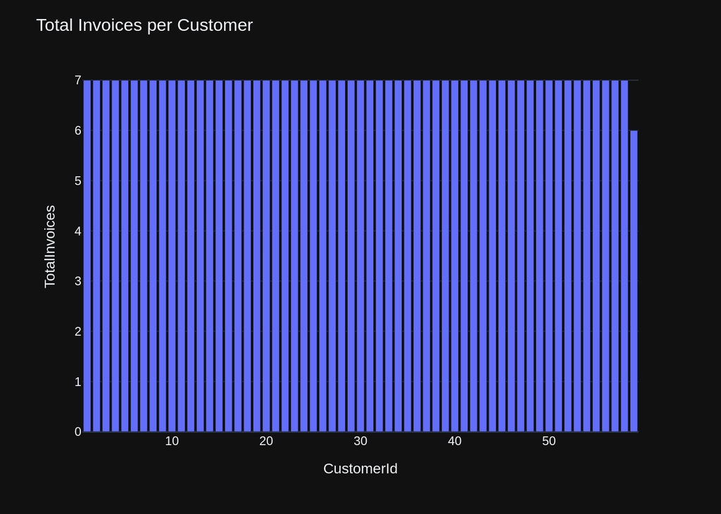

```
('SELECT CustomerId, COUNT(*) AS TotalInvoices\r\nFROM invoices\r\nGROUP BY CustomerId',
     CustomerId  TotalInvoices
 0            1              7
 1            2              7
 2            3              7
 3            4              7
 4            5              7
 5            6              7
 6            7              7
 7            8              7
 8            9              7
 9           10              7
 10          11              7
 11          12              7
 12          13              7
```

[output cut: 74 more lines]

```python
question = """
    Get the total number of invoices for each customer
"""

vn.ask(question=question)
```

```
Number of requested results 10 is greater than number of elements in index 6, updating n_results = 6
Number of requested results 10 is greater than number of elements in index 1, updating n_results = 1
```

```
SQL Prompt: [{'role': 'system', 'content': 'You are a SQLite expert. Please help to generate a SQL query to answer the question. Your response should ONLY be based on the given context and follow the response guidelines and format instructions. \n===Tables \nCREATE TABLE "invoices"\r\n(\r\n    Invoi…
Info: Ollama parameters:
model=gemma2:latest,
options={},
keep_alive=None
Info: Prompt Content:
[{"role": "system", "content": "You are a SQLite expert. Please help to generate a SQL query to answer the question. Your response should ONLY be based on the given context and follow the response guidelines and format instructions. \n===Tables \nCREATE TABLE \"invoices\"\r\n(\r\n    InvoiceId INTEG…
Info: Ollama Response:
{'model': 'gemma2:latest', 'created_at': '2024-08-01T18:46:36.274099532Z', 'message': {'role': 'assistant', 'content': 'SELECT c.Country, COUNT(i.InvoiceId) AS TotalInvoices\r\nFROM customers c\r\nJOIN invoices i ON c.CustomerId = i.CustomerId\r\nGROUP BY c.Country; \n\n\n\n'}, 'done_reason': 'stop'…
LLM Response: SELECT c.Country, COUNT(i.InvoiceId) AS TotalInvoices
FROM customers c
JOIN invoices i ON c.CustomerId = i.CustomerId
GROUP BY c.Country;




Info: Output from LLM: SELECT c.Country, COUNT(i.InvoiceId) AS TotalInvoices
FROM customers c
JOIN invoices i ON c.CustomerId = i.CustomerId
GROUP BY c.Country;




Extracted SQL: SELECT c.Country, COUNT(i.InvoiceId) AS TotalInvoices
FROM customers c
JOIN invoices i ON c.CustomerId = i.CustomerId
GROUP BY c.Country
SELECT c.Country, COUNT(i.InvoiceId) AS TotalInvoices
FROM customers c
JOIN invoices i ON c.CustomerId = i.CustomerId
GROUP BY c.Country
           Country  TotalInvoices
0        Argentina              7
1        Australia              7
2          Austria              7
3          Belgium              7
4           Brazil             35
5           Canada             56
```

[output cut: 11 more lines]

````
17          Norway              7
18          Poland              7
19        Portugal             14
20           Spain              7
21          Sweden              7
22             USA             91
23  United Kingdom             21
Info: Ollama parameters:
model=gemma2:latest,
options={},
keep_alive=None
Info: Prompt Content:
[{"role": "system", "content": "The following is a pandas DataFrame that contains the results of the query that answers the question the user asked: '  \n    Find the total number of invoices per country:\n'\n\nThe DataFrame was produced using this query: SELECT c.Country, COUNT(i.InvoiceId) AS Tota…
Info: Ollama Response:
{'model': 'gemma2:latest', 'created_at': '2024-08-01T18:47:03.350328991Z', 'message': {'role': 'assistant', 'content': '```python\nimport plotly.express as px\n\nif df.shape[0] == 1:\n  fig = px.indicator(df, name="TotalInvoices", value=\'TotalInvoices\', title= "Total Invoices per Country")\nelse:\…
````

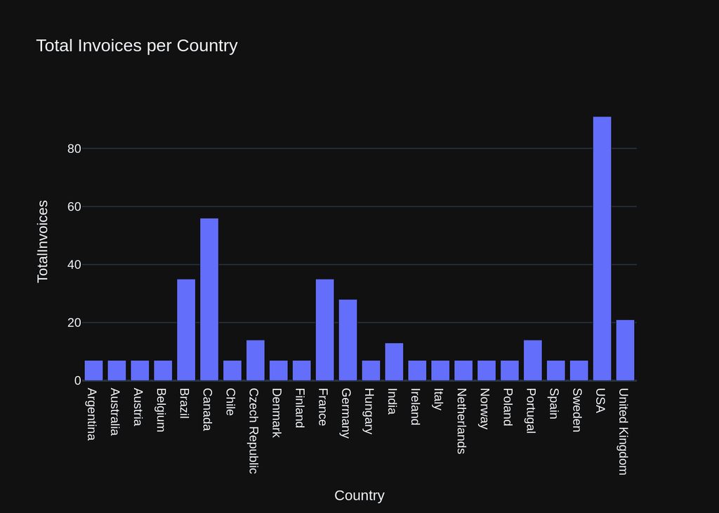

[output not shown]

```python
question = """
    Find the total number of invoices per country:
"""

vn.ask(question=question)
```

```python
question = """
    List all invoices with a total exceeding $10:
"""

vn.ask(question=question)
```

```
Number of requested results 10 is greater than number of elements in index 7, updating n_results = 7
Number of requested results 10 is greater than number of elements in index 1, updating n_results = 1
```

```
SQL Prompt: [{'role': 'system', 'content': 'You are a SQLite expert. Please help to generate a SQL query to answer the question. Your response should ONLY be based on the given context and follow the response guidelines and format instructions. \n===Tables \nCREATE TABLE "invoice_items"\r\n(\r\n    …
Info: Ollama parameters:
model=gemma2:latest,
options={},
keep_alive=None
Info: Prompt Content:
[{"role": "system", "content": "You are a SQLite expert. Please help to generate a SQL query to answer the question. Your response should ONLY be based on the given context and follow the response guidelines and format instructions. \n===Tables \nCREATE TABLE \"invoice_items\"\r\n(\r\n    InvoiceLin…
Info: Ollama Response:
{'model': 'gemma2:latest', 'created_at': '2024-08-01T18:48:07.452444868Z', 'message': {'role': 'assistant', 'content': 'SELECT * \r\nFROM invoices\r\nWHERE Total > 10;\n\n\n\n'}, 'done_reason': 'stop', 'done': True, 'total_duration': 63988670940, 'load_duration': 21220382, 'prompt_eval_count': 1394,…
LLM Response: SELECT *
FROM invoices
WHERE Total > 10;




Info: Output from LLM: SELECT *
FROM invoices
WHERE Total > 10;




Extracted SQL: SELECT *
FROM invoices
WHERE Total > 10
SELECT *
FROM invoices
WHERE Total > 10
    InvoiceId  CustomerId          InvoiceDate             BillingAddress  \
0           5          23  2009-01-11 00:00:00            69 Salem Street
1          12           2  2009-02-11 00:00:00    Theodor-Heuss-Straße 34
2          19          40  2009-03-14 00:00:00             8, Rue Hanovre
3          26          19  2009-04-14 00:00:00            1 Infinite Loop
4          33          57  2009-05-15 00:00:00            Calle Lira, 198
..        ...         ...                  ...                        ...
59        383          10  2013-08-12 00:00:00  Rua Dr. Falcão Filho, 155
60        390          48  2013-09-12 00:00:00      Lijnbaansgracht 120bg
61        397          27  2013-10-13 00:00:00            1033 N Park Ave
62        404           6  2013-11-13 00:00:00              Rilská 3174/6
```

[output cut: 10 more lines]

````
60   Amsterdam           VV     Netherlands              1016  13.86
61      Tucson           AZ             USA             85719  13.86
62      Prague         None  Czech Republic             14300  25.86
63    Helsinki         None         Finland             00530  13.86

[64 rows x 9 columns]
Info: Ollama parameters:
model=gemma2:latest,
options={},
keep_alive=None
Info: Prompt Content:
[{"role": "system", "content": "The following is a pandas DataFrame that contains the results of the query that answers the question the user asked: '  \n    List all invoices with a total exceeding $10:\n'\n\nThe DataFrame was produced using this query: SELECT * \r\nFROM invoices\r\nWHERE Total > 1…
Info: Ollama Response:
{'model': 'gemma2:latest', 'created_at': '2024-08-01T18:48:39.761153441Z', 'message': {'role': 'assistant', 'content': "```python\nimport plotly.express as px\n\nif df.shape[0] == 1:\n  px.indicator(\n      value=df['Total'].iloc[0],\n      title='Invoice Total',\n      mode='number',\n      color_d…
Couldn't run plotly code:  'NoneType' object has no attribute 'show'
````

[output not shown]

```
Number of requested results 10 is greater than number of elements in index 8, updating n_results = 8
Number of requested results 10 is greater than number of elements in index 1, updating n_results = 1
```

````
SQL Prompt: [{'role': 'system', 'content': 'You are a SQLite expert. Please help to generate a SQL query to answer the question. Your response should ONLY be based on the given context and follow the response guidelines and format instructions. \n===Tables \nCREATE TABLE "invoices"\r\n(\r\n    Invoi…
Info: Ollama parameters:
model=gemma2:latest,
options={},
keep_alive=None
Info: Prompt Content:
[{"role": "system", "content": "You are a SQLite expert. Please help to generate a SQL query to answer the question. Your response should ONLY be based on the given context and follow the response guidelines and format instructions. \n===Tables \nCREATE TABLE \"invoices\"\r\n(\r\n    InvoiceId INTEG…
Info: Ollama Response:
{'model': 'gemma2:latest', 'created_at': '2024-08-01T18:49:57.655386885Z', 'message': {'role': 'assistant', 'content': "SELECT SUM(Total) AS TotalInvoiced\r\nFROM invoices \r\nWHERE InvoiceDate >= '2010-01-01';\n\n\n\n"}, 'done_reason': 'stop', 'done': True, 'total_duration': 77831418315, 'load_dura…
LLM Response: SELECT SUM(Total) AS TotalInvoiced
FROM invoices
WHERE InvoiceDate >= '2010-01-01';




Info: Output from LLM: SELECT SUM(Total) AS TotalInvoiced
FROM invoices
WHERE InvoiceDate >= '2010-01-01';




Extracted SQL: SELECT SUM(Total) AS TotalInvoiced
FROM invoices
WHERE InvoiceDate >= '2010-01-01'
SELECT SUM(Total) AS TotalInvoiced
FROM invoices
WHERE InvoiceDate >= '2010-01-01'
   TotalInvoiced
0        1879.14
Info: Ollama parameters:
model=gemma2:latest,
options={},
keep_alive=None
Info: Prompt Content:
[{"role": "system", "content": "The following is a pandas DataFrame that contains the results of the query that answers the question the user asked: '  \n    Find all invoices since 2010 and the total amount invoiced:\n'\n\nThe DataFrame was produced using this query: SELECT SUM(Total) AS TotalInvoi…
Info: Ollama Response:
{'model': 'gemma2:latest', 'created_at': '2024-08-01T18:50:29.544861332Z', 'message': {'role': 'assistant', 'content': "```python\nimport plotly.graph_objects as go\n\nif df.shape[0] == 1:\n  fig = go.Figure(data=go.Indicator(value=df['TotalInvoiced'].iloc[0],\n                                    mo…
````

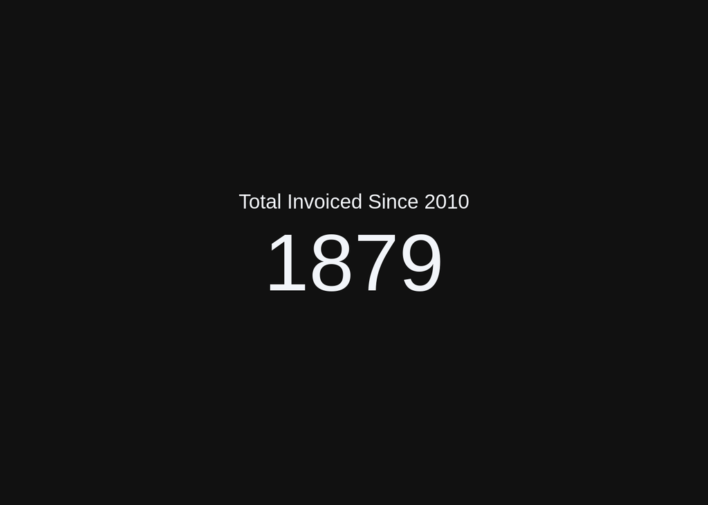

```
("SELECT SUM(Total) AS TotalInvoiced\r\nFROM invoices \r\nWHERE InvoiceDate >= '2010-01-01'",
    TotalInvoiced
 0        1879.14,
 Figure({
     'data': [{'mode': 'number', 'title': {'text': 'Total Invoiced Since 2010'}, 'type': 'indicator', 'value': 1879.14}],
     'layout': {'template': '...'}
 }))
```

```python
question = """
    Find all invoices since 2010 and the total amount invoiced:
"""

vn.ask(question=question)
```

```
Number of requested results 10 is greater than number of elements in index 9, updating n_results = 9
Number of requested results 10 is greater than number of elements in index 1, updating n_results = 1
```

````
SQL Prompt: [{'role': 'system', 'content': 'You are a SQLite expert. Please help to generate a SQL query to answer the question. Your response should ONLY be based on the given context and follow the response guidelines and format instructions. \n===Tables \nCREATE INDEX IFK_EmployeeReportsTo ON "em…
Info: Ollama parameters:
model=gemma2:latest,
options={},
keep_alive=None
Info: Prompt Content:
[{"role": "system", "content": "You are a SQLite expert. Please help to generate a SQL query to answer the question. Your response should ONLY be based on the given context and follow the response guidelines and format instructions. \n===Tables \nCREATE INDEX IFK_EmployeeReportsTo ON \"employees\" (…
Info: Ollama Response:
{'model': 'gemma2:latest', 'created_at': '2024-08-01T18:51:53.124651661Z', 'message': {'role': 'assistant', 'content': "SELECT e.FirstName AS EmployeeFirstName, e.LastName AS EmployeeLastName, \n       CASE WHEN e.ReportsTo IS NULL THEN 'None' ELSE (SELECT FirstName || ' ' || LastName FROM employees…
LLM Response: SELECT e.FirstName AS EmployeeFirstName, e.LastName AS EmployeeLastName,
       CASE WHEN e.ReportsTo IS NULL THEN 'None' ELSE (SELECT FirstName || ' ' || LastName FROM employees WHERE EmployeeId = e.ReportsTo) END AS ManagerName
FROM employees e;
Info: Output from LLM: SELECT e.FirstName AS EmployeeFirstName, e.LastName AS EmployeeLastName,
       CASE WHEN e.ReportsTo IS NULL THEN 'None' ELSE (SELECT FirstName || ' ' || LastName FROM employees WHERE EmployeeId = e.ReportsTo) END AS ManagerName
FROM employees e;
Extracted SQL: SELECT e.FirstName AS EmployeeFirstName, e.LastName AS EmployeeLastName,
       CASE WHEN e.ReportsTo IS NULL THEN 'None' ELSE (SELECT FirstName || ' ' || LastName FROM employees WHERE EmployeeId = e.ReportsTo) END AS ManagerName
FROM employees e
SELECT e.FirstName AS EmployeeFirstName, e.LastName AS EmployeeLastName,
       CASE WHEN e.ReportsTo IS NULL THEN 'None' ELSE (SELECT FirstName || ' ' || LastName FROM employees WHERE EmployeeId = e.ReportsTo) END AS ManagerName
FROM employees e
  EmployeeFirstName EmployeeLastName       ManagerName
0            Andrew            Adams              None
1             Nancy          Edwards      Andrew Adams
2              Jane          Peacock     Nancy Edwards
3          Margaret             Park     Nancy Edwards
4             Steve          Johnson     Nancy Edwards
5           Michael         Mitchell      Andrew Adams
6            Robert             King  Michael Mitchell
7             Laura         Callahan  Michael Mitchell
Info: Ollama parameters:
model=gemma2:latest,
options={},
keep_alive=None
Info: Prompt Content:
[{"role": "system", "content": "The following is a pandas DataFrame that contains the results of the query that answers the question the user asked: '  \n    List all employees and their reporting manager's name (if any):\n'\n\nThe DataFrame was produced using this query: SELECT e.FirstName AS Emplo…
Info: Ollama Response:
{'model': 'gemma2:latest', 'created_at': '2024-08-01T18:52:18.89328394Z', 'message': {'role': 'assistant', 'content': '```python\nimport plotly.express as px\n\nif df.shape[0] == 1:\n  fig = px.indicator(df, \n                    name="Employee", \n                    value="ManagerName")\nelse:\n  …
````

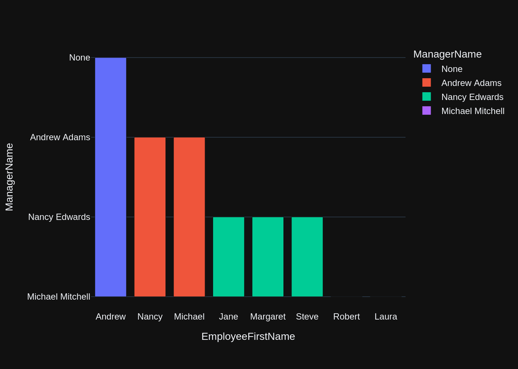

[output not shown]

[output cut: 24 more lines]

[output not shown]

```python
question = """
    List all employees and their reporting manager's name (if any):
"""

vn.ask(question=question)
```

```
Number of requested results 10 is greater than number of elements in index 1, updating n_results = 1
```

```
SQL Prompt: [{'role': 'system', 'content': 'You are a SQLite expert. Please help to generate a SQL query to answer the question. Your response should ONLY be based on the given context and follow the response guidelines and format instructions. \n===Tables \nCREATE TABLE "invoices"\r\n(\r\n    Invoi…
Info: Ollama parameters:
model=gemma2:latest,
options={},
keep_alive=None
Info: Prompt Content:
[{"role": "system", "content": "You are a SQLite expert. Please help to generate a SQL query to answer the question. Your response should ONLY be based on the given context and follow the response guidelines and format instructions. \n===Tables \nCREATE TABLE \"invoices\"\r\n(\r\n    InvoiceId INTEG…
Info: Ollama Response:
{'model': 'gemma2:latest', 'created_at': '2024-08-01T18:53:26.434932376Z', 'message': {'role': 'assistant', 'content': 'SELECT CustomerId, AVG(Total) AS AverageInvoiceTotal\r\nFROM invoices\r\nGROUP BY CustomerId; \n\n\n'}, 'done_reason': 'stop', 'done': True, 'total_duration': 67425285207, 'load_du…
LLM Response: SELECT CustomerId, AVG(Total) AS AverageInvoiceTotal
FROM invoices
GROUP BY CustomerId;



Info: Output from LLM: SELECT CustomerId, AVG(Total) AS AverageInvoiceTotal
FROM invoices
GROUP BY CustomerId;



Extracted SQL: SELECT CustomerId, AVG(Total) AS AverageInvoiceTotal
FROM invoices
GROUP BY CustomerId
SELECT CustomerId, AVG(Total) AS AverageInvoiceTotal
FROM invoices
GROUP BY CustomerId
    CustomerId  AverageInvoiceTotal
0            1             5.660000
1            2             5.374286
2            3             5.660000
3            4             5.660000
4            5             5.802857
5            6             7.088571
6            7             6.088571
7            8             5.374286
8            9             5.374286
9           10             5.374286
10          11             5.374286
11          12             5.374286
```

[output cut: 40 more lines]

````
52          53             5.374286
53          54             5.374286
54          55             5.374286
55          56             5.374286
56          57             6.660000
57          58             5.517143
58          59             6.106667
Info: Ollama parameters:
model=gemma2:latest,
options={},
keep_alive=None
Info: Prompt Content:
[{"role": "system", "content": "The following is a pandas DataFrame that contains the results of the query that answers the question the user asked: '  \n    Get the average invoice total for each customer:\n'\n\nThe DataFrame was produced using this query: SELECT CustomerId, AVG(Total) AS AverageIn…
Info: Ollama Response:
{'model': 'gemma2:latest', 'created_at': '2024-08-01T18:53:48.142612611Z', 'message': {'role': 'assistant', 'content': '```python\nimport plotly.express as px\n\nif df.shape[0] == 1:\n  fig = px.indicator(df, name="AverageInvoiceTotal", value="AverageInvoiceTotal")\nelse:\n  fig = px.bar(df, x="Cust…
````

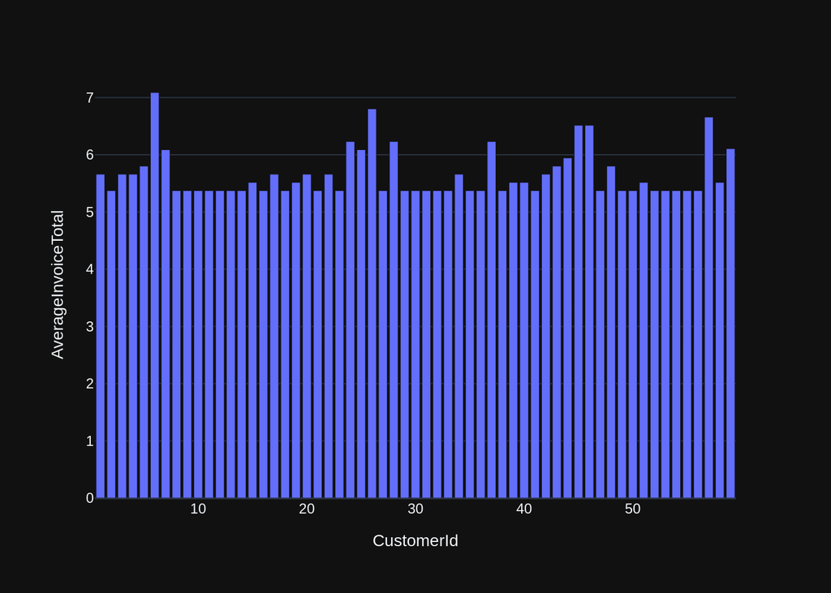

```
('SELECT CustomerId, AVG(Total) AS AverageInvoiceTotal\r\nFROM invoices\r\nGROUP BY CustomerId',
     CustomerId  AverageInvoiceTotal
 0            1             5.660000
 1            2             5.374286
 2            3             5.660000
 3            4             5.660000
 4            5             5.802857
 5            6             7.088571
 6            7             6.088571
 7            8             5.374286
 8            9             5.374286
 9           10             5.374286
 10          11             5.374286
 11          12             5.374286
 12          13             5.374286
 13          14             5.374286
 14          15             5.517143
 15          16             5.374286
 16          17             5.660000
 17          18             5.374286
 18          19             5.517143
 19          20             5.660000
 20          21             5.374286
 21          22             5.660000
 22          23             5.374286
 23          24             6.231429
 24          25             6.088571
 25          26             6.802857
 26          27             5.374286
 27          28             6.231429
 28          29             5.374286
 29          30             5.374286
 30          31             5.374286
 31          32             5.374286
 32          33             5.374286
 33          34             5.660000
 34          35             5.374286
 35          36             5.374286
 36          37             6.231429
 37          38             5.374286
```

[output cut: 40 more lines]

[output not shown]

```python
question = """
    Get the average invoice total for each customer:
"""

vn.ask(question=question)
```

```python
question = """
    Find the top 5 most expensive tracks (based on unit price):
"""

vn.ask(question=question)
```

```
Number of requested results 10 is greater than number of elements in index 1, updating n_results = 1
```

````
SQL Prompt: [{'role': 'system', 'content': 'You are a SQLite expert. Please help to generate a SQL query to answer the question. Your response should ONLY be based on the given context and follow the response guidelines and format instructions. \n===Tables \nCREATE TABLE "tracks"\r\n(\r\n    TrackId…
Info: Ollama parameters:
model=gemma2:latest,
options={},
keep_alive=None
Info: Prompt Content:
[{"role": "system", "content": "You are a SQLite expert. Please help to generate a SQL query to answer the question. Your response should ONLY be based on the given context and follow the response guidelines and format instructions. \n===Tables \nCREATE TABLE \"tracks\"\r\n(\r\n    TrackId INTEGER P…
Info: Ollama Response:
{'model': 'gemma2:latest', 'created_at': '2024-08-01T18:54:48.001329999Z', 'message': {'role': 'assistant', 'content': 'SELECT Name, UnitPrice\r\nFROM tracks\r\nORDER BY UnitPrice DESC\r\nLIMIT 5;\n\n\n\n'}, 'done_reason': 'stop', 'done': True, 'total_duration': 59765313922, 'load_duration': 2234252…
LLM Response: SELECT Name, UnitPrice
FROM tracks
ORDER BY UnitPrice DESC
LIMIT 5;




Info: Output from LLM: SELECT Name, UnitPrice
FROM tracks
ORDER BY UnitPrice DESC
LIMIT 5;




Extracted SQL: SELECT Name, UnitPrice
FROM tracks
ORDER BY UnitPrice DESC
LIMIT 5
SELECT Name, UnitPrice
FROM tracks
ORDER BY UnitPrice DESC
LIMIT 5
                                     Name  UnitPrice
0  Battlestar Galactica: The Story So Far       1.99
1                  Occupation / Precipice       1.99
2                           Exodus, Pt. 1       1.99
3                           Exodus, Pt. 2       1.99
4                           Collaborators       1.99
Info: Ollama parameters:
model=gemma2:latest,
options={},
keep_alive=None
Info: Prompt Content:
[{"role": "system", "content": "The following is a pandas DataFrame that contains the results of the query that answers the question the user asked: '  \n    Find the top 5 most expensive tracks (based on unit price):\n'\n\nThe DataFrame was produced using this query: SELECT Name, UnitPrice\r\nFROM …
Info: Ollama Response:
{'model': 'gemma2:latest', 'created_at': '2024-08-01T18:55:14.916472962Z', 'message': {'role': 'assistant', 'content': "```python\nimport plotly.express as px\n\nif df.shape[0] == 1:\n  px.indicator(\n    value=df['UnitPrice'].iloc[0],\n    name='Most Expensive Track Unit Price',\n    title='Top Tra…
Couldn't run plotly code:  'NoneType' object has no attribute 'show'
````

[output not shown]

```python
question = """
    List all genres and the number of tracks in each genre:
"""

vn.ask(question=question)
```

```
Number of requested results 10 is greater than number of elements in index 1, updating n_results = 1
```

[output not shown]

[output cut: 13 more lines]

[output not shown]

[output not shown]

```python
question = """
    Get all genres that do not have any tracks associated with them:
"""

vn.ask(question=question)
```

```
Number of requested results 10 is greater than number of elements in index 1, updating n_results = 1
```

[output not shown]

[output not shown]

```
Number of requested results 10 is greater than number of elements in index 1, updating n_results = 1
```

[output not shown]

[figure not shown]

```
('SELECT * \r\nFROM customers\r\nLEFT JOIN invoices ON customers.CustomerId = invoices.CustomerId\r\nWHERE InvoiceId IS NULL',
 Empty DataFrame
 Columns: [CustomerId, FirstName, LastName, Company, Address, City, State, Country, PostalCode, Phone, Fax, Email, SupportRepId, InvoiceId, CustomerId, InvoiceDate, BillingAddress, BillingCity, BillingState, BillingCountry, BillingPostalCode, Total]
 Index: []

 [0 rows x 22 columns],
 Figure({
     'data': [{'alignmentgroup': 'True',
               'hovertemplate': 'LastName=%{x}<br>FirstName=%{y}<extra></extra>',
               'legendgroup': '',
               'marker': {'color': '#636efa', 'pattern': {'shape': ''}},
               'name': '',
               'offsetgroup': '',
               'orientation': 'v',
               'showlegend': False,
               'textposition': 'auto',
               'type': 'bar',
               'x': array([], dtype=object),
               'xaxis': 'x',
               'y': array([], dtype=object),
               'yaxis': 'y'}],
     'layout': {'barmode': 'relative',
                'legend': {'tracegroupgap': 0},
                'template': '...',
                'title': {'text': 'Customers with No Orders'},
                'xaxis': {'anchor': 'y', 'domain': [0.0, 1.0], 'title': {'text': 'LastName'}},
                'yaxis': {'anchor': 'x', 'domain': [0.0, 1.0], 'title': {'text': 'FirstName'}}}
 }))
```

```python
question = """
    List all customers who have not placed any orders:
"""

vn.ask(question=question)
```

```python
question = """
    There are 3 tables: artists, albums and tracks, where albums and artists are linked by ArtistId, albums and tracks are linked by AlbumId,
    Can you find the top 10 most popular artists based on the number of tracks
"""

vn.ask(question=question)
```

```
Number of requested results 10 is greater than number of elements in index 1, updating n_results = 1
```

[output not shown]

[output not shown]

```
Number of requested results 10 is greater than number of elements in index 1, updating n_results = 1
```

[output not shown]

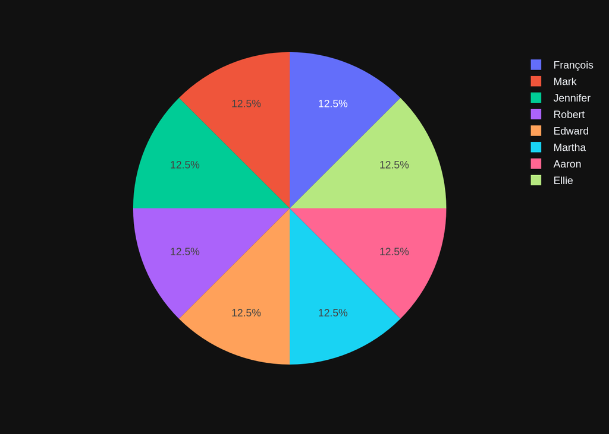

```
("SELECT FirstName, LastName, Email \r\nFROM customers \r\nWHERE Country = 'Canada'",
   FirstName  LastName                   Email
 0  François  Tremblay     ftremblay@gmail.com
 1      Mark   Philips      mphilips12@shaw.ca
 2  Jennifer  Peterson     jenniferp@rogers.ca
 3    Robert     Brown        robbrown@shaw.ca
 4    Edward   Francis     edfrancis@yachoo.ca
 5    Martha      Silk    marthasilk@gmail.com
 6     Aaron  Mitchell  aaronmitchell@yahoo.ca
 7     Ellie  Sullivan  ellie.sullivan@shaw.ca,
 Figure({
     'data': [{'domain': {'x': [0.0, 1.0], 'y': [0.0, 1.0]},
               'hovertemplate': 'FirstName=%{label}<extra></extra>',
               'labels': array(['François', 'Mark', 'Jennifer', 'Robert', 'Edward', 'Martha', 'Aaron',
                                'Ellie'], dtype=object),
               'legendgroup': '',
               'name': '',
               'showlegend': True,
               'type': 'pie'}],
     'layout': {'legend': {'tracegroupgap': 0}, 'margin': {'t': 60}, 'template': '...'}
 }))
```

```python
question = """
     List all customers from Canada and their email addresses:
"""

vn.ask(question=question)
```

```
Number of requested results 10 is greater than number of elements in index 1, updating n_results = 1
```

[output not shown]

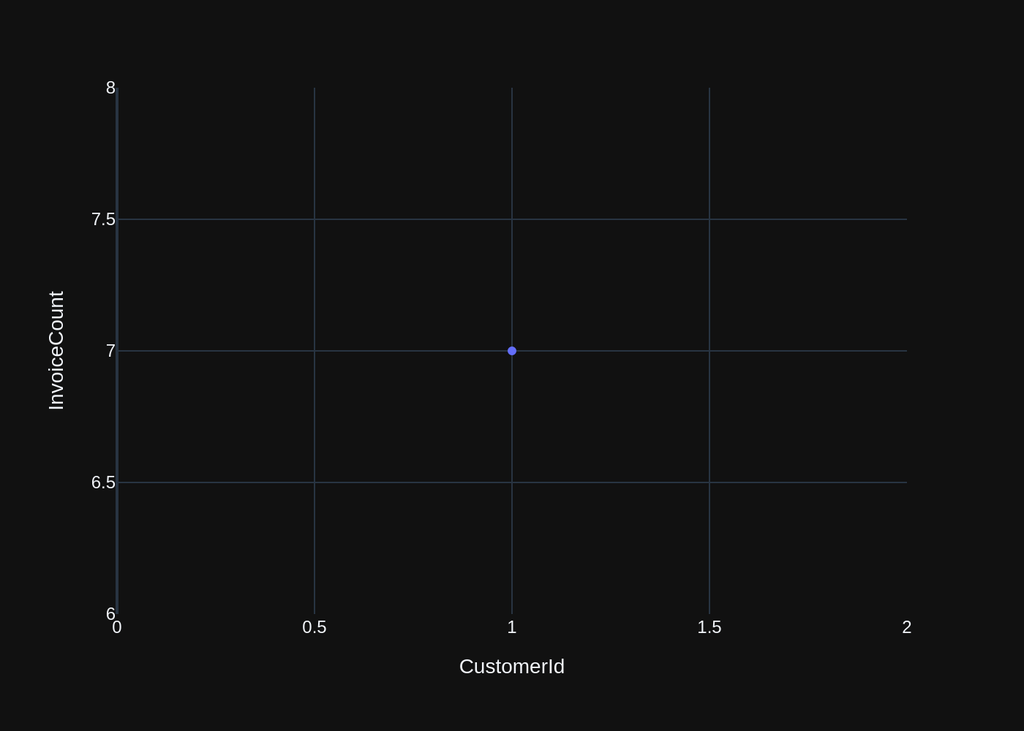

```
('SELECT CustomerId, COUNT(*) AS InvoiceCount\r\nFROM invoices\r\nGROUP BY CustomerId\r\nORDER BY InvoiceCount DESC\r\nLIMIT 1',
    CustomerId  InvoiceCount
 0           1             7,
 Figure({
     'data': [{'hovertemplate': 'CustomerId=%{x}<br>InvoiceCount=%{y}<extra></extra>',
               'legendgroup': '',
               'marker': {'color': '#636efa', 'symbol': 'circle'},
               'mode': 'markers',
               'name': '',
               'orientation': 'v',
               'showlegend': False,
               'type': 'scatter',
               'x': array([1]),
               'xaxis': 'x',
               'y': array([7]),
               'yaxis': 'y'}],
     'layout': {'legend': {'tracegroupgap': 0},
                'margin': {'t': 60},
                'template': '...',
                'xaxis': {'anchor': 'y', 'domain': [0.0, 1.0], 'title': {'text': 'CustomerId'}},
                'yaxis': {'anchor': 'x', 'domain': [0.0, 1.0], 'title': {'text': 'InvoiceCount'}}}
 }))
```

```python
question = """
     Find the customer with the most invoices
"""

vn.ask(question=question)
```

### Advanced SQL questions

```
Number of requested results 10 is greater than number of elements in index 1, updating n_results = 1
```

[output not shown]

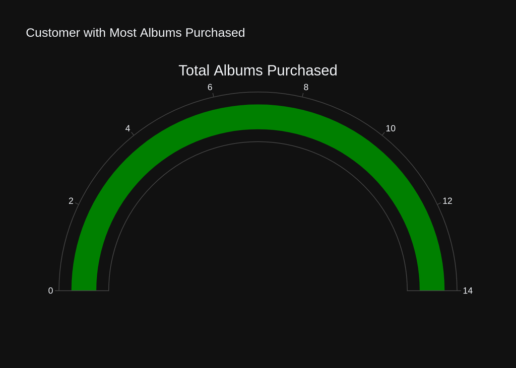

```
('SELECT c.CustomerId, SUM(ii.Quantity) AS TotalAlbumsPurchased\r\nFROM customers c\r\nJOIN invoice_items ii ON c.CustomerId = ii.InvoiceId\r\nGROUP BY c.CustomerId\r\nORDER BY TotalAlbumsPurchased DESC\r\nLIMIT 1',
    CustomerId  TotalAlbumsPurchased
 0           5                    14,
 Figure({
     'data': [{'gauge': {'axis': {'range': [0, 14]}},
               'mode': 'gauge',
               'title': {'text': 'Total Albums Purchased'},
               'type': 'indicator',
               'value': 14}],
     'layout': {'template': '...', 'title': {'text': 'Customer with Most Albums Purchased'}}
 }))
```

```python
question = """
     Find the customer who bought the most albums in total quantity (across all invoices):
"""

vn.ask(question=question)
```

```
Number of requested results 10 is greater than number of elements in index 1, updating n_results = 1
```

[output not shown]

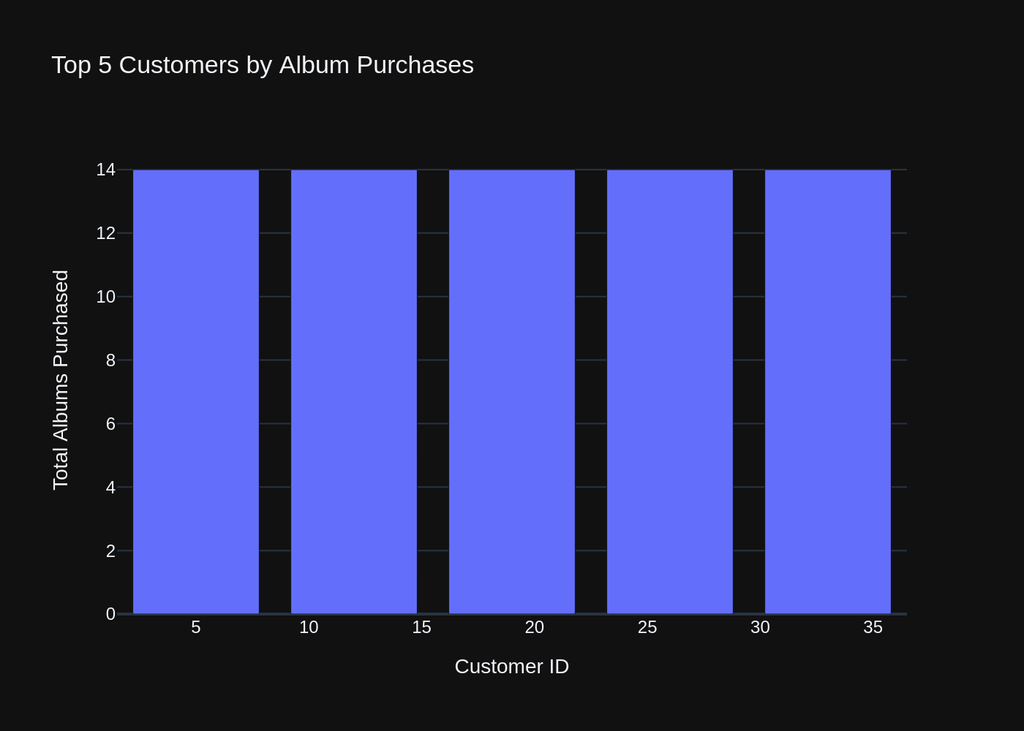

```
('SELECT c.CustomerId, SUM(ii.Quantity) AS TotalAlbumsPurchased\r\nFROM customers c\r\nJOIN invoice_items ii ON c.CustomerId = ii.InvoiceId\r\nGROUP BY c.CustomerId\r\nORDER BY TotalAlbumsPurchased DESC\r\nLIMIT 5  \n\n\n\n',
    CustomerId  TotalAlbumsPurchased
 0           5                    14
 1          12                    14
 2          19                    14
 3          26                    14
 4          33                    14,
 Figure({
     'data': [{'alignmentgroup': 'True',
               'hovertemplate': 'CustomerId=%{x}<br>TotalAlbumsPurchased=%{y}<extra></extra>',
               'legendgroup': '',
               'marker': {'color': '#636efa', 'pattern': {'shape': ''}},
               'name': '',
               'offsetgroup': '',
               'orientation': 'v',
               'showlegend': False,
               'textposition': 'auto',
               'type': 'bar',
               'x': array([ 5, 12, 19, 26, 33]),
               'xaxis': 'x',
               'y': array([14, 14, 14, 14, 14]),
               'yaxis': 'y'}],
     'layout': {'barmode': 'relative',
                'legend': {'tracegroupgap': 0},
                'template': '...',
                'title': {'text': 'Top 5 Customers by Album Purchases'},
                'xaxis': {'anchor': 'y', 'domain': [0.0, 1.0], 'title': {'text': 'Customer ID'}},
                'yaxis': {'anchor': 'x', 'domain': [0.0, 1.0], 'title': {'text': 'Total Albums Purchased'}}}
 }))
```

```python
question = """
    Hint: album quantity is found in invoice_items,

    Find the top 5 customers who bought the most albums in total quantity (across all invoices):
"""

vn.ask(question=question)
```

```
SELECT c.CustomerId, SUM(il.Quantity) AS TotalAlbums
FROM Customers c
JOIN invoices i  ON c.CustomerId = i.CustomerId
JOIN invoice_items il ON i.InvoiceId = il.InvoiceId
GROUP BY c.CustomerId
ORDER BY TotalAlbums DESC
LIMIT 5
```

```
Number of requested results 10 is greater than number of elements in index 1, updating n_results = 1
```

[output not shown]

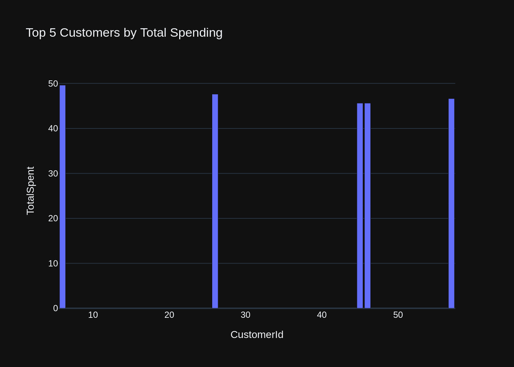

```
('SELECT c.CustomerId, SUM(i.Total) AS TotalSpent\r\nFROM customers c\r\nJOIN invoices i ON c.CustomerId = i.CustomerId\r\nGROUP BY c.CustomerId\r\nORDER BY TotalSpent DESC\r\nLIMIT 5  \n\n\n\n',
    CustomerId  TotalSpent
 0           6       49.62
 1          26       47.62
 2          57       46.62
 3          45       45.62
 4          46       45.62,
 Figure({
     'data': [{'alignmentgroup': 'True',
               'hovertemplate': 'CustomerId=%{x}<br>TotalSpent=%{y}<extra></extra>',
               'legendgroup': '',
               'marker': {'color': '#636efa', 'pattern': {'shape': ''}},
               'name': '',
               'offsetgroup': '',
               'orientation': 'v',
               'showlegend': False,
               'textposition': 'auto',
               'type': 'bar',
               'x': array([ 6, 26, 57, 45, 46]),
               'xaxis': 'x',
               'y': array([49.62, 47.62, 46.62, 45.62, 45.62]),
               'yaxis': 'y'}],
     'layout': {'barmode': 'relative',
                'legend': {'tracegroupgap': 0},
                'template': '...',
                'title': {'text': 'Top 5 Customers by Total Spending'},
                'xaxis': {'anchor': 'y', 'domain': [0.0, 1.0], 'title': {'text': 'CustomerId'}},
                'yaxis': {'anchor': 'x', 'domain': [0.0, 1.0], 'title': {'text': 'TotalSpent'}}}
 }))
```

```python
question = """
     Find the top 5 customers who spent the most money overall,

     Hint: order total can be found on invoices table, calculation using invoice_items detail table is unnecessary
"""

vn.ask(question=question)
```

```
Number of requested results 10 is greater than number of elements in index 1, updating n_results = 1
```

[output not shown]

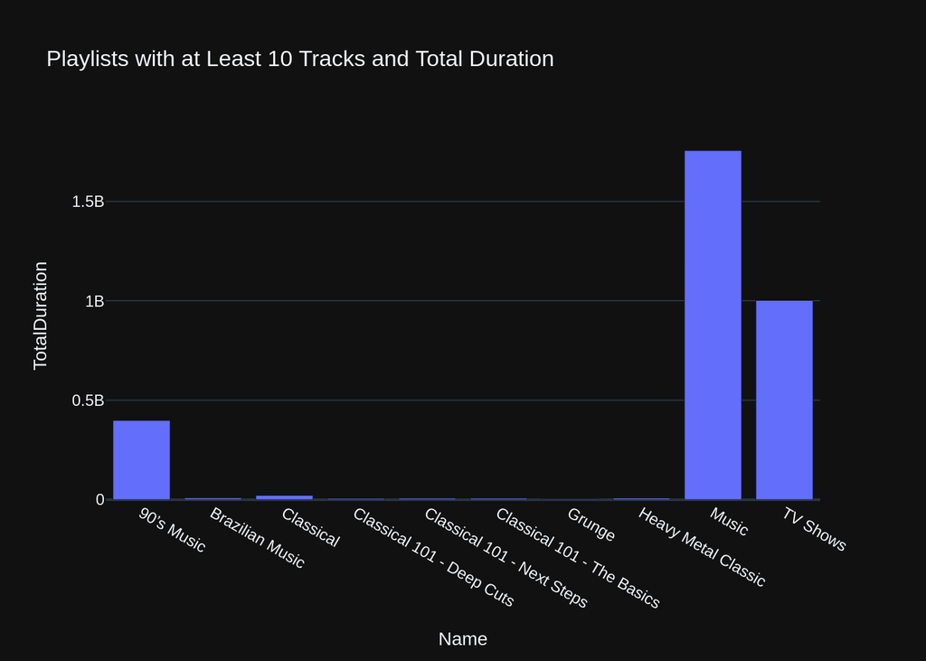

```
('SELECT p.Name, SUM(t.Milliseconds) AS TotalDuration\r\nFROM playlists p\r\nJOIN playlist_track pt ON p.PlaylistId = pt.PlaylistId\r\nJOIN tracks t ON pt.TrackId = t.TrackId\r\nGROUP BY p.Name\r\nHAVING COUNT(*) >= 10',
                          Name  TotalDuration
 0                  90’s Music      398705153
 1             Brazilian Music        9486559
 2                   Classical       21770592
 3   Classical 101 - Deep Cuts        6755730
 4  Classical 101 - Next Steps        7575051
 5  Classical 101 - The Basics        7439811
 6                      Grunge        4122018
 7         Heavy Metal Classic        8206312
 8                       Music     1755366166
 9                    TV Shows     1002189914,
 Figure({
     'data': [{'alignmentgroup': 'True',
               'hovertemplate': 'Name=%{x}<br>TotalDuration=%{y}<extra></extra>',
               'legendgroup': '',
               'marker': {'color': '#636efa', 'pattern': {'shape': ''}},
               'name': '',
               'offsetgroup': '',
               'orientation': 'v',
               'showlegend': False,
               'textposition': 'auto',
               'type': 'bar',
               'x': array(['90’s Music', 'Brazilian Music', 'Classical',
                           'Classical 101 - Deep Cuts', 'Classical 101 - Next Steps',
                           'Classical 101 - The Basics', 'Grunge', 'Heavy Metal Classic', 'Music',
                           'TV Shows'], dtype=object),
               'xaxis': 'x',
               'y': array([ 398705153,    9486559,   21770592,    6755730,    7575051,    7439811,
                              4122018,    8206312, 1755366166, 1002189914]),
               'yaxis': 'y'}],
     'layout': {'barmode': 'relative',
                'legend': {'tracegroupgap': 0},
                'template': '...',
                'title': {'text': 'Playlists with at Least 10 Tracks and Total Duration'},
                'xaxis': {'anchor': 'y', 'domain': [0.0, 1.0], 'title': {'text': 'Name'}},
                'yaxis': {'anchor': 'x', 'domain': [0.0, 1.0], 'title': {'text': 'TotalDuration'}}}
 }))
```

```python
question = """
     Get all playlists containing at least 10 tracks and the total duration of those tracks:
"""

vn.ask(question=question)
```

```
Number of requested results 10 is greater than number of elements in index 1, updating n_results = 1
```

[output not shown]

[output cut: 12 more lines]

[output not shown]

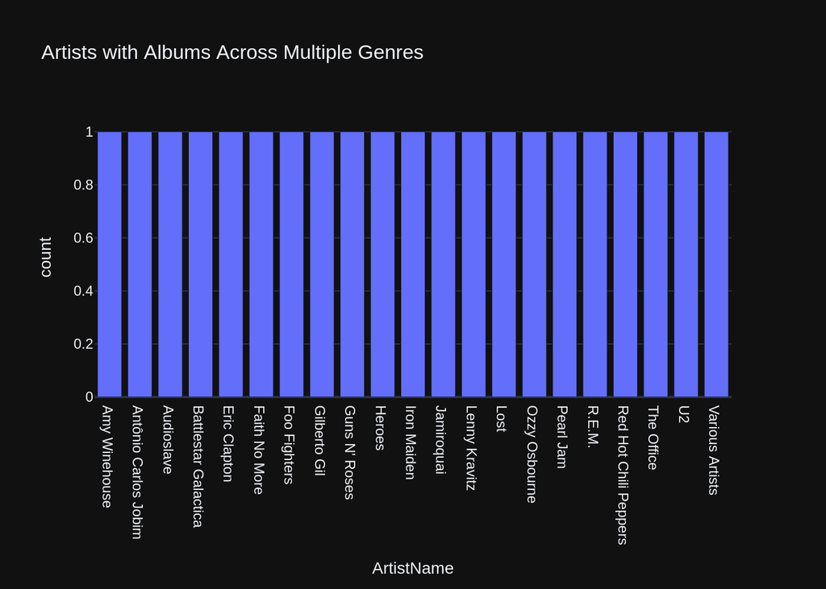

```
('SELECT DISTINCT a.Name AS ArtistName \r\nFROM artists a\r\nJOIN albums al ON a.ArtistId = al.ArtistId\r\nJOIN tracks t ON al.AlbumId = t.AlbumId\r\nGROUP BY a.Name\r\nHAVING COUNT(DISTINCT t.GenreId) > 1',
                ArtistName
 0           Amy Winehouse
 1    Antônio Carlos Jobim
 2              Audioslave
 3    Battlestar Galactica
 4            Eric Clapton
 5           Faith No More
 6            Foo Fighters
 7            Gilberto Gil
 8           Guns N' Roses
 9                  Heroes
 10            Iron Maiden
 11             Jamiroquai
 12          Lenny Kravitz
 13                   Lost
 14          Ozzy Osbourne
 15              Pearl Jam
 16                 R.E.M.
 17  Red Hot Chili Peppers
 18             The Office
 19                     U2
 20        Various Artists,
 Figure({
     'data': [{'alignmentgroup': 'True',
               'hovertemplate': 'ArtistName=%{x}<br>count=%{y}<extra></extra>',
               'legendgroup': '',
               'marker': {'color': '#636efa', 'pattern': {'shape': ''}},
               'name': '',
               'offsetgroup': '',
               'orientation': 'v',
               'showlegend': False,
               'textposition': 'auto',
               'type': 'bar',
               'x': array(['Amy Winehouse', 'Antônio Carlos Jobim', 'Audioslave',
                           'Battlestar Galactica', 'Eric Clapton', 'Faith No More', 'Foo Fighters',
                           'Gilberto Gil', "Guns N' Roses", 'Heroes', 'Iron Maiden', 'Jamiroquai',
                           'Lenny Kravitz', 'Lost', 'Ozzy Osbourne', 'Pearl Jam', 'R.E.M.',
                           'Red Hot Chili Peppers', 'The Office', 'U2', 'Various Artists'],
                          dtype=object),
               'xaxis': 'x',
               'y': array([1, 1, 1, 1, 1, 1, 1, 1, 1, 1, 1, 1, 1, 1, 1, 1, 1, 1, 1, 1, 1]),
               'yaxis': 'y'}],
     'layout': {'barmode': 'relative',
                'legend': {'tracegroupgap': 0},
                'template': '...',
                'title': {'text': 'Artists with Albums Across Multiple Genres'},
                'xaxis': {'anchor': 'y', 'domain': [0.0, 1.0], 'title': {'text': 'ArtistName'}},
                'yaxis': {'anchor': 'x', 'domain': [0.0, 1.0], 'title': {'text': 'count'}}}
 }))
```

```python
question = """
     Identify artists who have albums with tracks appearing in multiple genres:


"""

vn.ask(question=question)
```

### Check completion time

```python
from datetime import datetime
import os
hostname = os.uname().nodename
print("Hostname:", hostname)
```

```
Hostname: ducklover1
```

```python
ts_stop = time()

elapsed_time = ts_stop - ts_start
print(f"test running on '{hostname}' with '{model_name}' LLM took : {elapsed_time:.2f} sec")
```

```
test running on 'ducklover1' with 'gemma2' LLM took : 2267.60 sec
```

```python
print(f"[{datetime.now()}] test on '{hostname}' with '{model_name}' LLM took : {elapsed_time:.2f} sec")
```

[output not shown]

test running on 'ducklover1' with 'gemma2' LLM took : 2267.60 sec

## Launch the User Interface

[figure not shown]

## Next Steps

Using Vanna via Jupyter notebooks is great for getting started but check out additional customizable interfaces like the

- [Streamlit app](https://github.com/vanna-ai/vanna-streamlit)
- [Flask app](https://github.com/vanna-ai/vanna-flask)
- [Slackbot](https://github.com/vanna-ai/vanna-slack)